# Olympic_project

2026-10-07

# Phase 1: Environment Setup & Data Loading

To kick off our analysis, we load the four sheets from our Excel workbook (`olympics.xlsx`) using `readxl` and inspect their structure.

```r
library(tidyverse)
library(readxl)

games    <- read_excel("olympics.xlsx", sheet = "games")
athletes <- read_excel("olympics.xlsx", sheet = "athletes")
country  <- read_excel("olympics.xlsx", sheet = "country")
medals   <- read_excel("olympics.xlsx", sheet = "medals")

glimpse(games)
```

```
## Rows: 52
## Columns: 4
## $ Games  <chr> "1992 Summer", "2012 Summer", "1920 Summer", "1900 Summer", "19…
## $ Year   <dbl> 1992, 2012, 1920, 1900, 1988, 1992, 1994, 1932, 2002, 1952, 198…
## $ Season <chr> "Summer", "Summer", "Summer", "Summer", "Winter", "Winter", "Wi…
## $ City   <chr> "Barcelona", "London", "Antwerpen", "Paris", "Calgary", "Albert…
```

## Part 1: Athletes Who Competed for Different Countries

To check if any athletes represented more than one country over time, I looked at the country table. Since every row in this table shows an athlete’s participation in a specific Games, I grouped the data by athlete_id and counted how many unique country codes (NOC) each person had. After that, I filtered for anyone with more than 1 country.

```r
# Group by athlete and count unique NOCs
multi_country_athletes <- country %>%
  group_by(athlete_id) %>%
  summarise(n_countries = n_distinct(NOC), .groups = "drop") %>%
  filter(n_countries > 1)

# Store count for inline R code and print to see the output
num_multi_country <- nrow(multi_country_athletes)
print(num_multi_country)
```

```
## [1] 1570
```

## Part 2: Athletes Who Participated in the Most Games

To find out which athletes took part in the highest number of Olympic Games, I looked at the country table. Since every row represents an athlete’s appearance at a specific Games, I grouped the data by athlete_id and counted how many unique Games each person attended. Then, I joined this with the athletes table to get their names and sorted the list to find the top 10.

```r
# Count unique Games per athlete, join with names, and get top 10
top_athletes_games <- country %>%
  group_by(athlete_id) %>%
  summarise(n_games = n_distinct(Games), .groups = "drop") %>%
  left_join(athletes, by = c("athlete_id" = "ID")) %>%
  arrange(desc(n_games)) %>%
  head(10)

# Print the top 10 results
print(top_athletes_games %>% select(Name, n_games, Sex))
```

```
## # A tibble: 10 × 3
##    Name                     n_games Sex
##    <chr>                      <int> <chr>
##  1 Ian Millar                    10 M
##  2 Afanasijs Kuzmins              9 M
##  3 Hubert Raudaschl               9 M
##  4 Francisco Boza Dibos           8 M
##  5 Rajmond Debevec                8 M
##  6 Piero D'Inzeo                  8 M
##  7 Raimondo D'Inzeo               8 M
##  8 Paul Bert Elvstrm              8 M
##  9 Josefa Idem-Guerrini           8 F
## 10 Durward Randolph Knowles       8 M
```

## Observations

Ian Millar holds the overall record with an impressive 10 Olympic appearances, representing Canada in show jumping across four decades. He is closely followed by Latvian shooter Afanasijs Kuzmins and Austrian sailor Hubert Raudaschl, who each competed in 9 Olympic Games.

Looking at this top 10 list, it is clear that many of these extremely long careers happen in sports like equestrian, shooting, and sailing, where physical endurance can be maintained over many decades compared to high-impact sports.

## Part 3: Athletes with the Most Events

To find out which ten athletes competed in the highest total number of events, I counted the number of event entries per athlete in the `medals` table. I joined this with the `athletes` table to get their names.

To check whether athletes participated in more than one event during a single Games, I calculated the number of events per athlete per Games edition.

```r
# 1. Top 10 athletes by total events competed in
top_athletes_events <- medals %>%
  group_by(athlete_id) %>%
  summarise(n_events = n(), .groups = "drop") %>%
  left_join(athletes, by = c("athlete_id" = "ID")) %>%
  arrange(desc(n_events)) %>%
  head(10)

print(top_athletes_events %>% select(Name, n_events, Sex))
```

```
## # A tibble: 10 × 3
##    Name                               n_events Sex
##    <chr>                                 <int> <chr>
##  1 "Robert Tait McKenzie"                   58 M
##  2 "Heikki Ilmari Savolainen"               39 M
##  3 "Joseph \"Josy\" Stoffel"                38 M
##  4 "Ioannis Theofilakis"                    36 M
##  5 "Alfrd (Arnold-) Hajs (Guttmann-)"       32 M
##  6 "Jean Lucien Nicolas Jacoby"             32 M
##  7 "Takashi Ono"                            32 M
##  8 "Alexandros Theofilakis"                 32 M
##  9 "Andreas Wecker"                         32 M
## 10 "Alfred August \"Al\" Jochim"            31 M
```

```r
# 2. Check if athletes compete in multiple events in a single Games
events_per_games <- medals %>%
  group_by(athlete_id, Games) %>%
  summarise(events_in_game = n(), .groups = "drop")

# Print max events competed by a single athlete in a single Games
max_events_in_single_games <- max(events_per_games$events_in_game)
print(paste("Maximum events in a single Games by one athlete:", max_events_in_single_games))
```

```
## [1] "Maximum events in a single Games by one athlete: 44"
```

### Observations

Looking at the table, Robert Tait McKenzie has the highest number of events with 58, followed by Heikki Savolainen with 39. Many of the top athletes on this list are gymnasts or shooter competitors.

Also, it turns out athletes definitely compete in more than one event during a single Games. The highest number of events for a single athlete in one Games was 44, which is pretty crazy!

## Part 4: Medals per Country and Year

Before jumping into building the top countries table, I checked the hint to see what happened in the 1956 Olympic Games.

### Investigating the 1956 Games

Looking at the `games` table for 1956, there are actually two different entries for the Summer Olympics:

```r
# Inspect 1956 entries in the games table
games %>%
  filter(Year == 1956)
```

```
## # A tibble: 3 × 4
##   Games        Year Season City
##   <chr>       <dbl> <chr>  <chr>
## 1 1956 Winter  1956 Winter Cortina d'Ampezzo
## 2 1956 Summer  1956 Summer Melbourne
## 3 1956 Summer  1956 Summer Stockholm
```

Because Games == “1956 Summer” appears twice in the games dataset, joining directly on Games causes duplicate rows. To avoid this, I used distinct() to grab unique Games and Year pairs.

### Top 15 Countries Medal Table

Now I can combine the datasets, find the top 15 countries with the most medals overall, and put the years as columns across the top.

```r
# 1. Combine tables safely (using distinct on games to fix the 1956 double entry)
medals_full <- medals %>%
  filter(!is.na(Medal)) %>%
  left_join(country, by = c("athlete_id", "Games")) %>%
  left_join(games %>% select(Games, Year) %>% distinct(), by = "Games")

# 2. Find the top 15 countries with the most total medals
top_15_countries <- medals_full %>%
  group_by(NOC) %>%
  summarise(total_medals = n(), .groups = "drop") %>%
  arrange(desc(total_medals)) %>%
  head(15) %>%
  pull(NOC)

# 3. Create the table with countries as rows and years as columns
medals_by_year <- medals_full %>%
  filter(NOC %in% top_15_countries) %>%
  group_by(NOC, Year) %>%
  summarise(n_medals = n(), .groups = "drop") %>%
  pivot_wider(names_from = Year, values_from = n_medals, values_fill = 0)

print(medals_by_year)
```

```
## # A tibble: 15 × 36
##    NOC   `1896` `1900` `1904` `1906` `1920` `1924` `1928` `1932` `1936` `1948`
##    <chr>  <int>  <int>  <int>  <int>  <int>  <int>  <int>  <int>  <int>  <int>
##  1 AUS        3      6      4      3      7     11      4      5      1     16
##  2 CAN        0      2     48      2     16     29     45     59     35     22
##  3 CHN        0      0      0      0      0      0      0      0      0      0
##  4 FRA       11    235      2     64    141    120     52     42     45     77
##  5 GBR        9    108      2     39    111     95     59     35     53     63
##  6 GDR        0      0      0      0      0      0      0      0      0      0
##  7 GER       32     45     16     30      0      0     82     57    231      0
##  8 HUN        6      5      4     13      0     22     21     35     43     64
##  9 ITA        0      5      0     56     84     51     72     77     76     68
## 10 NED        0     27      0      6     50     27     57     13     37     42
## 11 NOR        0      9      2     25    137     39     24     10     46     31
## 12 RUS        0      0      0      0      0      0      0      0      0      0
## 13 SWE        0      4      0     21    154     81     53     35     45     88
## 14 URS        0      0      0      0      0      0      0      0      0      0
## 15 USA       20     63    394     24    194    194    102    223    112    168
## # ℹ 25 more variables: `1952` <int>, `1956` <int>, `1960` <int>, `1964` <int>,
## #   `1968` <int>, `1972` <int>, `1976` <int>, `1980` <int>, `1984` <int>,
## #   `1988` <int>, `1992` <int>, `1994` <int>, `1996` <int>, `1998` <int>,
## #   `2000` <int>, `2002` <int>, `2004` <int>, `2006` <int>, `2008` <int>,
## #   `2010` <int>, `2012` <int>, `2014` <int>, `2016` <int>, `1908` <int>,
## #   `1912` <int>
```

Observations Looking at the table, there are a lot of zeros for certain countries in the early years. This is mostly because countries like the Soviet Union (URS) or East Germany (GDR) started competing under those country codes much later.

## Part 5

### Is there a relationship between country and the probability of winning a medal?

We know that some countries win more medals than others. In this part we want to work out whether some countries win more medals simply because they have more athletes competing for more events, or whether their athletes are in fact performing better in general.

For this part, look only at the top 15 countries that you established in the previous section.

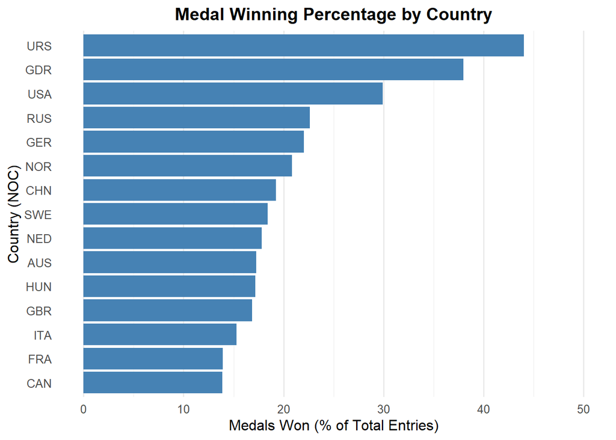

```r
library(ggplot2)

# 1. Join full medals table with country table to define all_entries
all_entries <- medals %>%
  left_join(country, by = c("athlete_id", "Games")) %>%
  filter(NOC %in% top_15_countries)

# 2. Compute winning percentage for top 15 countries
top15_data <- all_entries %>%
  group_by(NOC) %>%
  summarise(
    total_entries = n(),
    medals_won = sum(!is.na(Medal)),
    win_pct = (medals_won / total_entries) * 100,
    .groups = "drop"
  ) %>%
  mutate(NOC = reorder(NOC, win_pct))

# 3. Standard course-style ggplot2 horizontal bar chart
ggplot(top15_data, aes(x = win_pct, y = NOC)) +
  geom_col(fill = "steelblue") +
  labs(
    title = "Medal Winning Percentage by Country",
    x = "Medals Won (% of Total Entries)",
    y = "Country (NOC)"
  ) +
  xlim(0, 50) +
  theme_minimal(base_size = 12) +
  theme(
    panel.grid.major.y = element_blank(),
    plot.title = element_text(face = "bold", hjust = 0.5)
  )
```

## Chart Observations

Looking at the chart, there is a clear difference between countries:

- **Higher Efficiency:** Countries like URS (Soviet Union), GDR (East Germany), and USA have higher success rates per entry.
- **Lower Efficiency:** Other countries win fewer medals relative to how many events they enter.
- **Key Takeaway:** This suggests that winning medals is not just about sending more athletes; some countries have a higher performance efficiency per event.

## Chi-Square Test

To test this statistically, I ran a Chi-Square test to check if winning a medal is independent of the country.

- **Null Hypothesis ($H_0$):** There is no relationship between country and whether an entry wins a medal.
- **Alternative Hypothesis ($H_1$):** There is a relationship between country and winning a medal.

```r
# 1. Count medals won vs not won per country (reusing all_entries from above)
medal_counts <- all_entries %>%
  mutate(won = ifelse(!is.na(Medal), "Won", "No Medal")) %>%
  group_by(NOC, won) %>%
  summarise(count = n(), .groups = "drop") %>%
  pivot_wider(names_from = won, values_from = count, values_fill = 0)

# 2. Convert to matrix for chisq.test
test_matrix <- as.matrix(medal_counts[, c("Won", "No Medal")])
rownames(test_matrix) <- medal_counts$NOC

# 3. Run Chi-Square test
chisq.test(test_matrix)
```

```
##
##  Pearson's Chi-squared test
##
## data:  test_matrix
## X-squared = 4426.6, df = 14, p-value < 2.2e-16
```

### Statistical Test Interpretation

The test yielded a test statistic of $\chi^2 = 4426.6$ with 14 degrees of freedom, resulting in an extraordinarily small $p$-value ($p < 2.2 \times 10^{-16}$).

Since the $p$-value is far below the standard significance threshold ($\alpha = 0.05$), we reject the null hypothesis.

This statistical result strongly aligns with the observations from our bar chart: there is a highly significant relationship between a country and its probability of winning a medal per event entry.

## Part 6: Sport-Level Average Height vs. Average Weight and BMI Analysis

Physical traits (`Height` and `Weight`) reside in the `athletes` table, while event categories (`Sport`) are stored in the `medals` table. A `left_join()` was executed to connect individual competitor measurements with their specific sport categories, enabling accurate group-level aggregation and BMI calculations. To examine the physical profile of different sports, we calculated the average height, average weight, and Body Mass Index (BMI) for each sport. BMI is computed as:
$$\text{BMI} = \frac{\text{weight in
kg}}{(\text{height in meters})^2}$$

we plotted all sports as background points and selectively highlighted and labeled the sports with the extreme values (max/min height, weight, and BMI).

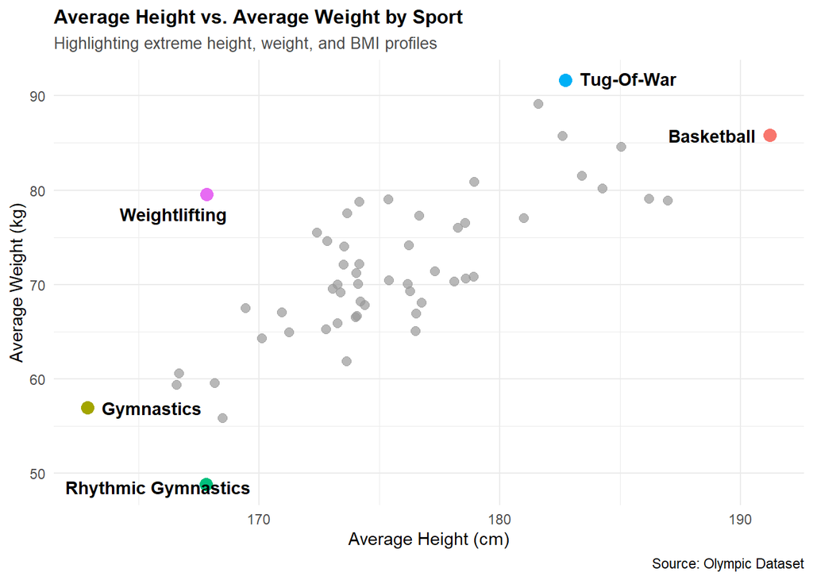

```r
library(ggrepel)

# 1. Join medals and athletes to connect physical attributes with sports, then calculate averages
sport_physical <- medals %>%
  left_join(athletes, by = c("athlete_id" = "ID")) %>%
  filter(!is.na(Height) & !is.na(Weight) & !is.na(Sport)) %>%
  group_by(Sport) %>%
  summarise(
    avg_height_cm = mean(Height, na.rm = TRUE),
    avg_weight_kg = mean(Weight, na.rm = TRUE),
    .groups = "drop"
  ) %>%
  mutate(
    avg_height_m = avg_height_cm / 100,
    avg_BMI = avg_weight_kg / (avg_height_m^2)
  )

# 2. Identify the specific sports meeting our extreme criteria
extreme_sports <- sport_physical %>%
  filter(
    avg_height_cm == max(avg_height_cm) |
    avg_height_cm == min(avg_height_cm) |
    avg_weight_kg == max(avg_weight_kg) |
    avg_weight_kg == min(avg_weight_kg) |
    avg_BMI       == max(avg_BMI)       |
    avg_BMI       == min(avg_BMI)
  )

# 3. Create the layered scatterplot
ggplot(sport_physical, aes(x = avg_height_cm, y = avg_weight_kg)) +
  # Layer 1: All sports as standard grey background points
  geom_point(color = "grey60", alpha = 0.7, size = 2.5) +
  # Layer 2: Extreme sports highlighted in a distinct color
  geom_point(data = extreme_sports, aes(color = Sport), size = 3.5, show.legend = FALSE) +
  # Layer 3: Labels for the extreme sports using ggrepel to prevent overlap
  geom_text_repel(
    data = extreme_sports,
    aes(label = Sport),
    box.padding = 0.5,
    point.padding = 0.3,
    fontface = "bold",
    max.overlaps = Inf
  ) +
  labs(
    title = "Average Height vs. Average Weight by Sport",
    subtitle = "Highlighting extreme height, weight, and BMI profiles",
    x = "Average Height (cm)",
    y = "Average Weight (kg)",
    caption = "Source: Olympic Dataset"
  ) +
  theme_minimal() +
  theme(
    plot.title = element_text(face = "bold", size = 12),
    plot.subtitle = element_text(size = 10, color = "grey30")
  )
```

## Part 7: Medal Distribution Over Time by Season

To examine how the distribution of medals has evolved over time, we aggregated the total number of Gold, Silver, and Bronze medals awarded per year. Using facets, we separated the trends between Summer and Winter Olympic Games to account for differences in scheduling and event expansion. The `medals` table records individual medal awards but lacks explicit chronological values. A `left_join()` on the shared `Games` key was used to append the calendar `Year` and operational `Season` (Summer vs. Winter) from the `games` table, allowing for precise time-series aggregation and faceting.

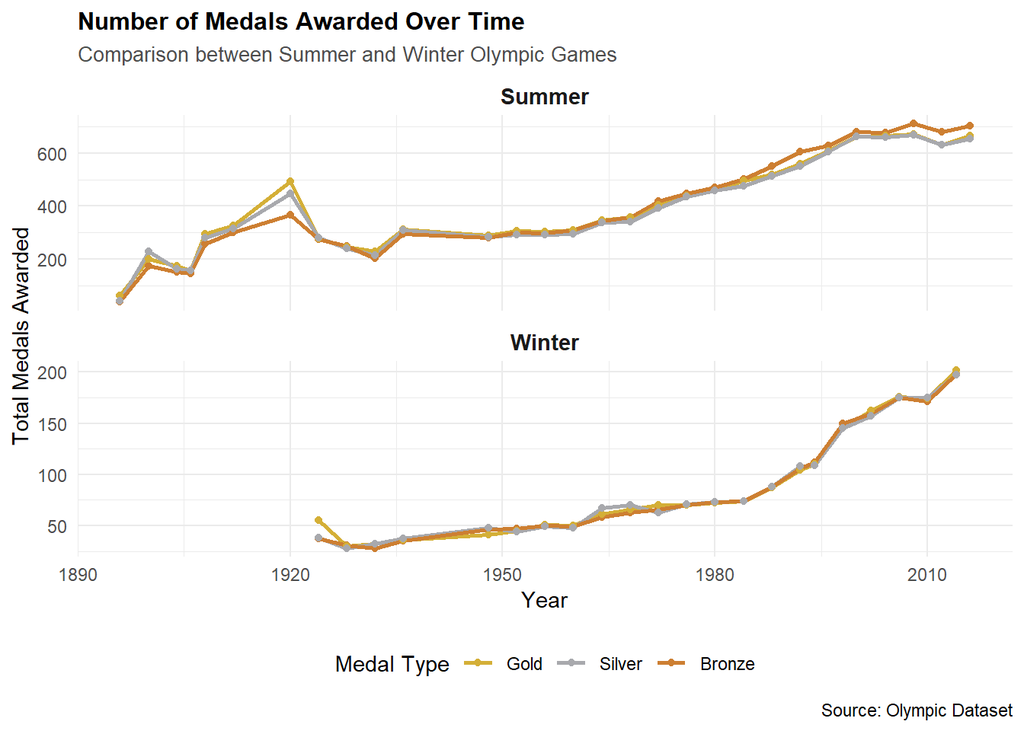

```r
# 1. Deduplicate games table to prevent row duplication on "1956 Summer"
games_clean <- games %>%
  select(Games, Year, Season) %>%
  distinct()

# 2. Join medals with cleaned games table and aggregate
medal_trends <- medals %>%
  left_join(games_clean, by = "Games") %>%
  filter(!is.na(Year) & !is.na(Medal) & !is.na(Season)) %>%
  mutate(Medal = str_to_title(Medal)) %>%
  filter(Medal %in% c("Gold", "Silver", "Bronze")) %>%
  group_by(Year, Season, Medal) %>%
  summarise(n_medals = n(), .groups = "drop")

# Ensure Medal is ordered logically
medal_trends$Medal <- factor(medal_trends$Medal, levels = c("Gold", "Silver", "Bronze"))

# 2. Create the faceted line plot
ggplot(medal_trends, aes(x = Year, y = n_medals, color = Medal)) +
  geom_line(linewidth = 1) +
  geom_point(size = 1.5) +
  facet_wrap(~ Season, scales = "free_y", ncol = 1) +
  scale_color_manual(values = c("Gold" = "#D4AF37", "Silver" = "#A8A9AD", "Bronze" = "#CD7F32")) +
  labs(
    title = "Number of Medals Awarded Over Time",
    subtitle = "Comparison between Summer and Winter Olympic Games",
    x = "Year",
    y = "Total Medals Awarded",
    color = "Medal Type",
    caption = "Source: Olympic Dataset"
  ) +
  theme_minimal() +
  theme(
    plot.title = element_text(face = "bold", size = 12),
    plot.subtitle = element_text(size = 10, color = "grey30"),
    strip.text = element_text(face = "bold", size = 11),
    legend.position = "bottom"
  )
```

### Interpretation of Results

The number of medals goes up over time because the Olympics added more events and sports as the years went on.

- **Summer vs. Winter:** The Summer games give out way more medals than the Winter games.
- **Medals:** Gold, Silver, and Bronze all follow the same pattern and stay pretty close together on the graph.